# Final Project

Elysa Strunin, Ekaterina Mikhailova, Shenrui Pan

## Gibbs sampling

We use inverse transform sampling here.
1. Generate our CDF:
$$F_{X|Y}=\frac{1-e^{-yx}}{1-e^{-yB}}$$
$$F_{Y|X}=\frac{1-e^{-xy}}{1-e^{-xB}}$$
2. Generate two samples from the uniform distribution between 0 and 1. Name them $P_{1}$ and $P_{1}$.
3. For each value $P_{1}$ and $P_{2}$ in uniform sample, generate new x and y. The rest of the implementation mirrors the implementation shown in class. Thinning the chain via thin=10 was deemed reasonable here as well.
$$x=-\frac{1}{y}log(1-p_{1}~+p_{1}~e^{-yB})$$
$$y=-\frac{1}{x}log(1-p_{2}+p_{2}~e^{-xB})$$

## T=500

In the following codes, the reason we commented all our codes about matplotlib is that we can not run this code in r Markdown although we can run them in the terminal. The figures we pasted here were gotten from the outcomes of terminal.

```
## The numpy matrix
## [[  0.00000000e+00   1.15919282e-01   1.68806133e+00]
##  [  1.00000000e+00   1.50146534e+00   1.07743965e-01]
##  [  2.00000000e+00   1.00537614e+00   1.50790759e+00]
##  ...,
##  [  4.97000000e+02   2.69978929e+00   2.15489291e-01]
##  [  4.98000000e+02   1.10747412e+00   7.85135360e-01]
##  [  4.99000000e+02   4.24415023e-04   2.60294283e+00]]
## The expectation of X
## 1.13107919304
## The expectation of Y
## 1.32905590016
```

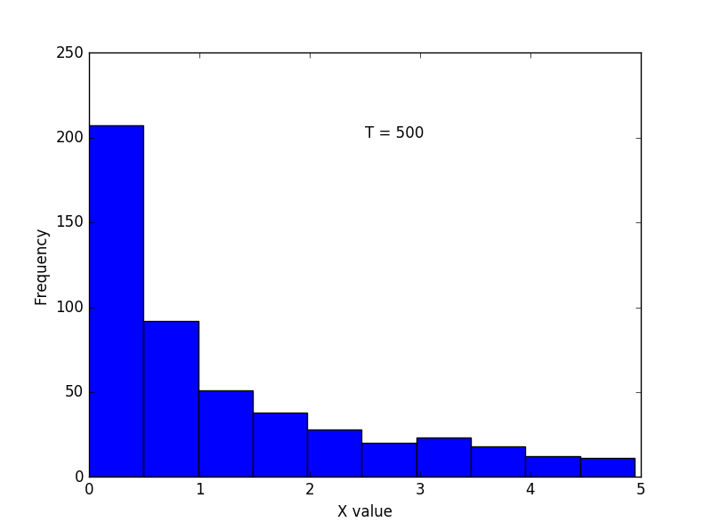

```python
from math import *
import random
import numpy
#import matplotlib.pyplot as plt

B = 5
T = 500
M = numpy.zeros((T, 3))

def gibbs(T,thin=10):
    x=1
    y=1
    for i in range(T):
        for j in range(thin):
            p1= random.uniform(0,1)
            x=-1/y*log(1-p1+p1*exp(-y*B))
            p2= random.uniform(0,1)
            y=-1/x*log(1-p2+p2*exp(-x*B))
        M[i,0] = i
        M[i,1] = x
        M[i,2] = y

gibbs(T)
print "The numpy matrix"
print M
print "The expectation of X"
print numpy.mean(M[:,1])
print "The expectation of Y"
print numpy.mean(M[:,2])
#plt.hist(M[:,1])
#plt.text(2.5,180,'T = 500')
#plt.xlabel('X value')
#plt.ylabel('Frequency')
#plt.show()
```

## T=5000

```
## The numpy matrix
## [[  0.00000000e+00   1.52191332e-01   4.01828956e+00]
##  [  1.00000000e+00   8.75700891e-01   2.65603933e-01]
##  [  2.00000000e+00   1.02478040e+00   5.28871725e-01]
##  ...,
##  [  4.99700000e+03   6.54651139e-01   3.29657691e+00]
##  [  4.99800000e+03   2.93258912e-01   4.82644253e+00]
##  [  4.99900000e+03   3.31031918e-02   3.04532127e-01]]
## The expectation of X
## 1.23981056357
## The expectation of Y
## 1.28631700034
```

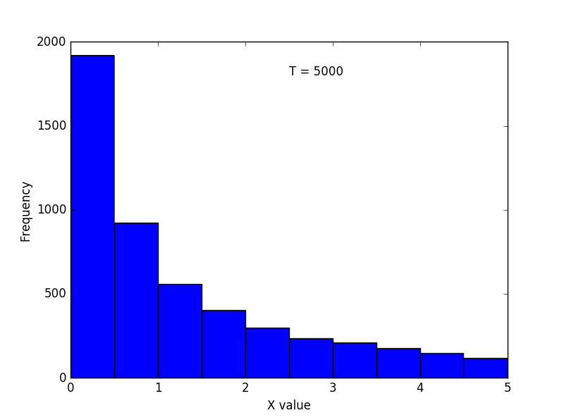

```python
from math import *
import random
import numpy
#import matplotlib.pyplot as plt

B = 5
T = 5000
M = numpy.zeros((T, 3))

def gibbs(T,thin=10):
    x=1
    y=1
    for i in range(T):
        for j in range(thin):
            p1= random.uniform(0,1)
            x=-1/y*log(1-p1+p1*exp(-y*B))
            p2= random.uniform(0,1)
            y=-1/x*log(1-p2+p2*exp(-x*B))
        M[i,0] = i
        M[i,1] = x
        M[i,2] = y

gibbs(T)
print "The numpy matrix"
print M
print "The expectation of X"
print numpy.mean(M[:,1])
print "The expectation of Y"
print numpy.mean(M[:,2])
#plt.hist(M[:,1])
#plt.text(2.5,1800,'T = 5000')
#plt.xlabel('X value')
#plt.ylabel('Frequency')
#plt.show()
```

## T=50000

```
## The numpy matrix
## [[  0.00000000e+00   3.36546888e+00   1.12979451e-01]
##  [  1.00000000e+00   1.57482776e+00   1.12212942e+00]
##  [  2.00000000e+00   7.95515638e-01   7.16858560e-02]
##  ...,
##  [  4.99970000e+04   1.61116528e-01   2.02278460e+00]
##  [  4.99980000e+04   3.24147791e+00   7.34912248e-01]
##  [  4.99990000e+04   1.18478354e+00   5.41701266e-01]]
## The expectation of X
## 1.26254570584
## The expectation of Y
## 1.26604746987
```

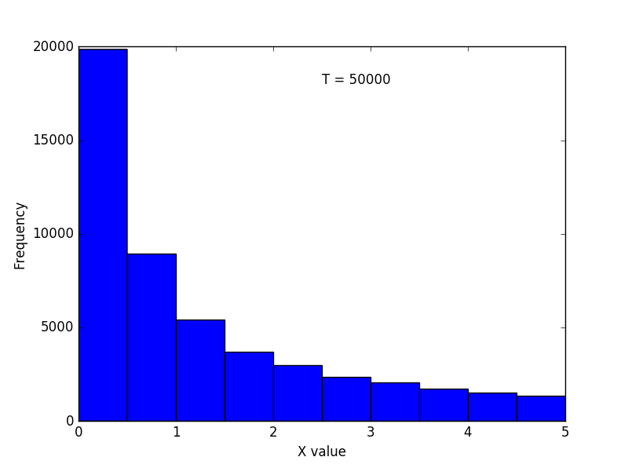

```python
from math import *
import random
import numpy
#import matplotlib.pyplot as plt

B = 5
T = 50000
M = numpy.zeros((T, 3))

def gibbs(T,thin=10):
    x=1
    y=1
    for i in range(T):
        for j in range(thin):
            p1= random.uniform(0,1)
            x=-1/y*log(1-p1+p1*exp(-y*B))
            p2= random.uniform(0,1)
            y=-1/x*log(1-p2+p2*exp(-x*B))
        M[i,0] = i
        M[i,1] = x
        M[i,2] = y

gibbs(T)
print "The numpy matrix"
print M
print "The expectation of X"
print numpy.mean(M[:,1])
print "The expectation of Y"
print numpy.mean(M[:,2])
#plt.hist(M[:,1])
#plt.text(2.5,18000,'T = 50000')
#plt.xlabel('X value')
#plt.ylabel('Frequency')
#plt.show()
```

As sample size T increases, the histogram showing X outputs appears less lumpy; it more closely resembles a smooth distribution, as we would expect. Our estimate of the expectation of X appears to increase in accuracy as T increases. As a test we estimated the expectation of Y as well, which we assumed would be the same value (given the symmetry of the CDFs). Both expectations trended toward approximately 1.26 as T increased, which was promising.